# CS109B Lab 0: Intro to R and Rstudio

# Basic plotting

Base R comes with a full suite of graphics capabilities. The entry point is usually the `plot()` function, perhaps followed by calls to `points()`, `lines()` etc. It looks like this:

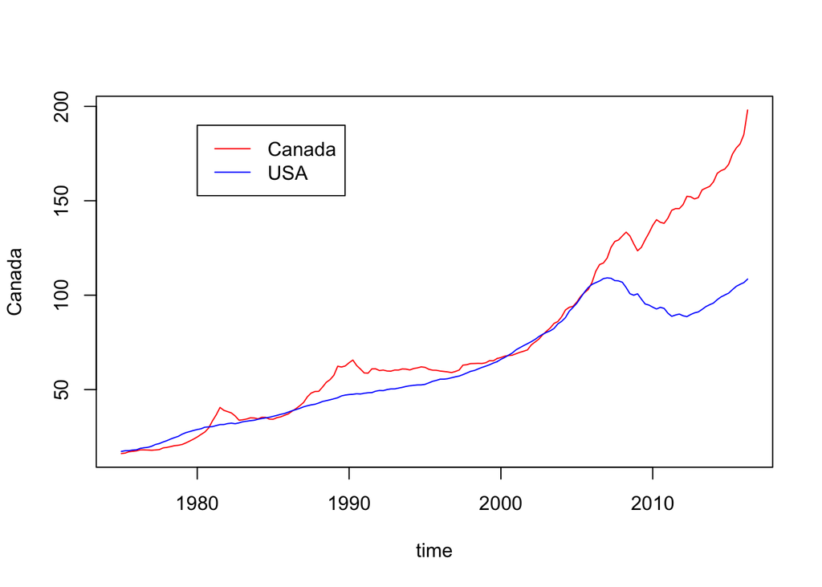

```r
plot(Canada ~ time, data = housing,
     type = "l", col = "red")
lines(US ~ time, col = "blue", data = housing)
legend(1980, 190, legend = c("Canada", "USA"), lty = 1, col = c("red", "blue"))
```

That’s not too bad, and the system in general is very flexible. It is however pretty low level. Over the last 10 years or so the `ggplot2` package has become the preferred graphics system for many useRs, and it is the system we will use in this class.

The `ggplot()` version of the graph above looks like this:

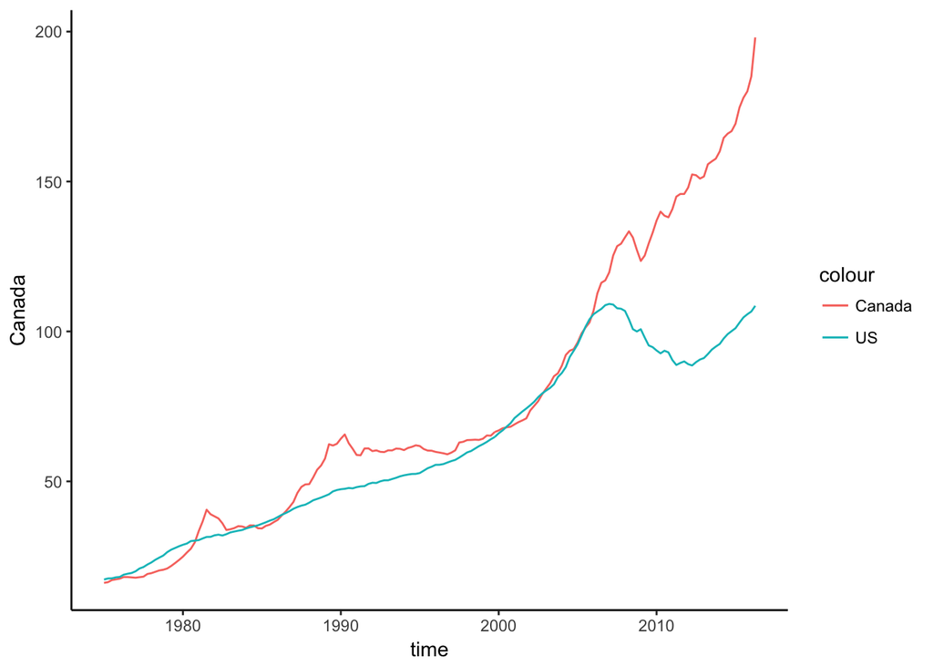

```r
library(ggplot2)
theme_set(theme_classic())

ggplot(housing, mapping = aes(x = time)) +
  geom_line(mapping = aes(y = Canada, color = "Canada")) +
  geom_line(mapping = aes(y = US, color = "US"))
```

The main advantages are a) inheritance so we don’t have to specify the same parameters multiple times and b) automatic construction of the legend.

The most important advantage of the *ggplot* system isn’t yet apparent in the plot we made above. For that we need to normalize or “tidy” our data into a form with one column per variable and one row per observation. There are various ways to do this in R; the `gather_()` function in the *tidyr* package is popular and easy.

```r
library(tidyr)
housing.l <- gather_(housing,
                     key_col = "country",
                     value_col = "hpi",
                     gather_cols = names(housing)[-(1:3)])

head(housing.l)
```

```
## # A tibble: 6 x 5
##    year quarter  time country     hpi
##   <int> <chr>   <dbl> <chr>     <dbl>
## 1  1975 Q1       1975 Australia  7.60
## 2  1975 Q2       1975 Australia  7.74
## 3  1975 Q3       1976 Australia  8.04
## 4  1975 Q4       1976 Australia  8.30
## 5  1976 Q1       1976 Australia  8.58
## 6  1976 Q2       1976 Australia  8.83
```

Now that the data has been arranged into a more friendly form, we can map country to color directly.

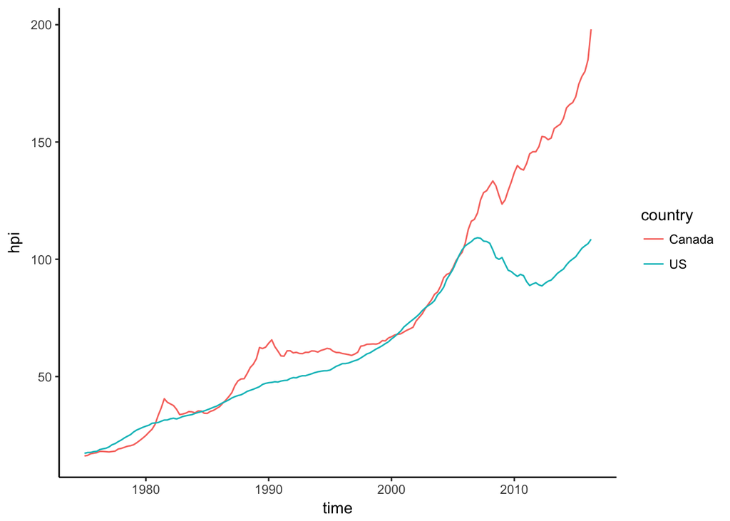

```r
ggplot(housing.l[housing.l$country %in% c("Canada", "US"), ],
       mapping = aes(x = time, y = hpi)) +
  geom_line(mapping = aes(y = hpi, color = country))
```

This makes the graph easy to reason about and easy to extend:

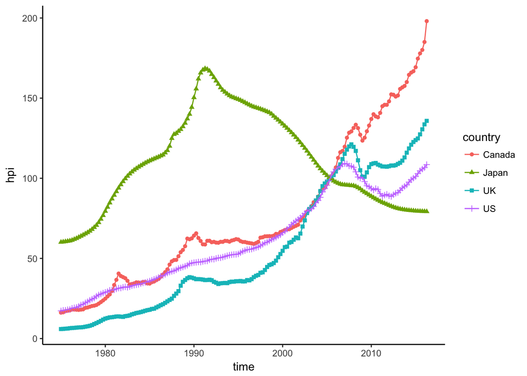

```r
ggplot(housing.l[housing.l$country %in% c("Canada", "US", "UK", "Japan"), ],
       mapping = aes(x = time, y = hpi, shape = country, color = country)) +
  geom_point() +
  geom_line()
```

# Writing your own functions

Defining functions in R is relatively easy. Writing functions is useful both as a way of avoiding encapsulating frequently used code, and because you sometimes need to pass a function as an argument to other functions.

As a example of the second case, we can use a *split-apply* strategy to calculate average hdi year, like this:

```r
sapply(split(housing.l$hpi, housing.l[c("year")]), mean)
```

```
##      1975      1976      1977      1978      1979      1980      1981
##  15.82804  17.24163  19.02402  20.92467  22.97152  25.27674  27.89359
##      1982      1983      1984      1985      1986      1987      1988
##  28.97489  30.56728  32.14587  33.92772  35.91250  38.14967  42.30239
##      1989      1990      1991      1992      1993      1994      1995
##  47.36228  50.81250  52.76380  52.66837  54.13250  56.36924  57.84076
##      1996      1997      1998      1999      2000      2001      2002
##  59.62054  61.92109  64.45076  67.53043  70.97978  74.38391  79.69130
##      2003      2004      2005      2006      2007      2008      2009
##  85.39293  92.44565 100.00043 108.96870 116.39054 117.55457 114.71761
##      2010      2011      2012      2013      2014      2015      2016
## 118.60283 120.03272 120.11511 123.14011 127.66804 133.50076 138.30283
```

but what if we want to calculate both means and standard deviations? There is no function that does that, but we need to pass a function to `sapply`. So we create one, like this:

```r
meansd <- function(x) {
    xm <- mean(x)
    xsd <- sd(x)
    c(mean = xm, sd = xsd)
}

sapply(split(housing.l$hpi, housing.l[c("year")]), meansd)
```

```
##          1975     1976     1977     1978     1979     1980     1981
## mean 15.82804 17.24163 19.02402 20.92467 22.97152 25.27674 27.89359
## sd   15.77659 15.94049 16.76243 17.77948 19.09247 20.66330 22.59965
##          1982     1983     1984     1985     1986     1987     1988
## mean 28.97489 30.56728 32.14587 33.92772 35.91250 38.14967 42.30239
## sd   23.90185 24.83243 25.06141 24.99664 25.42706 26.65923 28.43871
##          1989     1990     1991     1992     1993     1994     1995
## mean 47.36228 50.81250 52.76380 52.66837 54.13250 56.36924 57.84076
## sd   30.41464 32.89138 33.95001 32.07242 29.29251 28.11308 27.53473
##          1996     1997     1998     1999     2000     2001     2002
## mean 59.62054 61.92109 64.45076 67.53043 70.97978 74.38391 79.69130
## sd   26.71357 25.69597 23.95946 22.35619 19.71416 17.37273 15.02336
##          2003      2004      2005       2006      2007     2008      2009
## mean 85.39293 92.445652 100.00043 108.968696 116.39054 117.5546 114.71761
## sd   11.11330  6.183191   2.82619   6.520439  10.61972  11.6165  12.90514
##           2010      2011      2012      2013      2014     2015      2016
## mean 118.60283 120.03272 120.11511 123.14011 127.66804 133.5008 138.30283
## sd    18.08317  22.04795  25.36385  29.27242  32.50695  36.3989  39.76531
```

Here are some things to keep in mind when writing functions in R.

- Be careful not to use the same name as an existing function or you will silently over-write it.
- The return value is the value of the last evaluated expression.
- Your function can only return one “thing”; if you want to return multiple things put them in a vector or list.
- Arguments can have default values; these can be functions of other arguments.

# Your turn: More housing stats

1. Write a function that returns a named vector containing the *min* *median* and *max* of its argument.
2. Use your function to calculate the minimum, median, and maximum of HDI in the US
3. Iterate, using your function to calculate the minimum, median, and maximum of HDI for all countries.
4. (Advanced) Graph the median HDI across time.
5. (Advanced) Graph the min, median, and max HDI across time.

# Lab Survey

Please fill this out at the end of lab each week. This will be anonymous and will NOT be used for attendance. At the end you will have the opporutnity to leave any unanswered questions. If enough people ask the same question I will post an answer in supplementary material.

https://goo.gl/forms/ght49e1v419Jopua2